# ATiG 2026: PCA Exercise using bedpca — worked answers

*Rendering note: figures and answers use the verified full-data PCA fit of 9 September 2026. The teaching material was refreshed without recomputing the fits.*

## What you will learn

Use PCA to describe genetic variation in this reference panel, explain why relatedness and LD affect the fit, and distinguish fitting PCs from projecting additional individuals. We compute 20 PCs for exploration; this does not establish how many covariates a GWAS needs.

The data are a previously filtered subset of the 1000 Genomes Project, with 2,490 individuals and 1,664,852 variants. Their population labels describe the reference panel and do not partition all human genetic variation into discrete categories. Budget about 20 minutes for the full computation on two cores, plus time to discuss the results.

Work through four stages: identify related samples, fit and interpret PCs, assess outliers, and project excluded samples back. Before running each stage, write down what you expect to change. Afterwards, check the output and explain one result in your own words.

Keep your code, annotated plots and answers in one R Markdown file. Your final product is a short analysis note in Q14 that distinguishes what these PCs show from what they cannot establish. Questions Q5, Q8 and Q12 can be discussed while the PCA runs.

The workflow follows the [bigsnpr PCA vignette](https://privefl.github.io/bigsnpr/articles/bedpca.html) and [Privé et al. (2020)](https://doi.org/10.1093/bioinformatics/btaa520).

## Setup

Use a current R installation and RStudio. Open this file and choose **Knit to HTML**. When running chunks interactively, set the working directory to this file’s folder (RStudio: **Session > Set Working Directory > To Source File Location**).

Install the following packages once:

```r
install.packages(c("bigsnpr", "ggplot2", "cowplot", "knitr", "rmarkdown"))
```

The first run downloads about 1 GB of genotype data plus PLINK 2; later runs reuse the files in `data/`. The analysis reads genotypes from disk and uses two cores by default.

First we load the packages.

```r
library(bigsnpr)
library(ggplot2)
```

## 1. Identify related samples

**Before running:** why might a large family influence PCA more than the same number of unrelated individuals?

First we download the 1000 genomes data in plink bed file format, which can take time if the internet connection is slow.

```r
dir.create("data", showWarnings = FALSE)
bedfile <- download_1000G("data")
```

### Q1: What are plink bed files?

A bed file is one of the three primary PLINK files: .bed, .bim, and .fam, used to store and manipulate large-scale genotype data. The bed file stores the actual genotype (0, 1, 2) information in a highly efficient binary format. The bim file stores chromosome, variant ID, genetic position, physical position, and alleles A1/A2. These are not guaranteed to be reference/alternative alleles; see the [PLINK file-format reference](https://www.cog-genomics.org/plink/1.9/formats#bim). Finally, the fam file stores information about the samples (individuals) in the study (family ID, individual ID, paternal ID, maternal ID, sex, phenotype (control/case/missing 1/2/-9)). Paternal and maternal IDs are often 0 when unknown. The phenotype field can also contain a quantitative trait; its interpretation depends on the analysis.

### Estimate relatedness

First, let us detect all pairs of related individuals by filtering on the kinship coefficient. Note that the kinship coefficient is the probability that a pair of randomly sampled homologous alleles are identical by descent (IBD). In pedigree terms, the coefficient of relatedness is twice the kinship coefficient. An estimated genomic relationship matrix depends on its allele-frequency reference and is not automatically twice a KING estimate.

```r
plink2 <- download_plink2("data",
                          ARM = grepl("aarch64|arm64", R.version$arch),
                          AVX2 = FALSE)
# Keep relative paths: the course folder itself may contain spaces.
plink2 <- file.path("data", basename(plink2))
rel <- snp_plinkKINGQC(
  plink2.path = plink2,
  bedfile.in = bedfile,
  thr.king = 2^-4.5,
  make.bed = FALSE,
  ncores = ncores
)
str(rel)
```

### Q2: What threshold was used to filter related individuals? What level of relatedness does it correspond to?

The cutoff is 2^-4.5 (approximately 0.0442). These pedigree values provide a guide; estimated KING kinship is not an exact pedigree label for every pair. This threshold corresponds to filtering out third-degree relationships or closer (e.g., great-grandparents). See `?snp_plinkKINGQC`

0.5 corresponds to duplicates or monozygotic twins.

~0.25 corresponds to first-degree relations (e.g., parent-child, full siblings).

~0.125 corresponds to second-degree relations (e.g., half-siblings, grandparents, aunts/uncles).

~0.0625 corresponds to third-degree relations (e.g., great-grandparents)

~0.03125 corresponds to fourth-degree relations (e.g., great-great-grandparents)

### Q3: How does the relatedness cutoff change the result?

Plot the reported kinship values and compare cutoffs 2^-4.5 and 2^-3.5. Explain why the higher cutoff flags fewer pairs. Does `rel` contain every possible pair, or only pairs above the original cutoff? Could it be used to evaluate a *lower* cutoff?

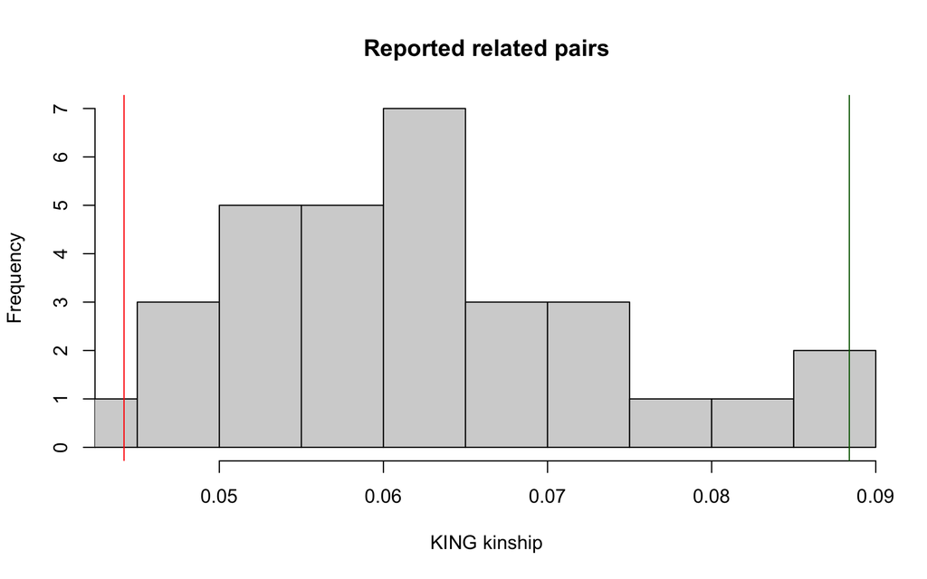

Figure 1. Reported kinship estimates and the two filtering thresholds.

```r
hist(rel$KINSHIP, xlab = "KING kinship", main = "Reported related pairs",
     xlim = range(c(rel$KINSHIP, 2^-4.5, 2^-3.5)))
abline(v = c(2^-4.5, 2^-3.5), col = c("red", "darkgreen"))
```

Anything to the right of the red line would be considered too closely related and would be filtered out when using the 2^-4.5 threshold. Meanwhile, anything to the right of the green line would be considered too closely related and would be filtered out when using the less stringent 2^-3.5 threshold. Let us check how many pairs exceed the higher threshold:

```r
# The higher cutoff is a subset of the pairs already reported.
rel2 <- rel[rel$KINSHIP > 2^-3.5, , drop = FALSE]
str(rel2)
```

```
## 'data.frame':    0 obs. of  8 variables:
##  $ FID1   : int
##  $ IID1   : chr
##  $ FID2   : int
##  $ IID2   : chr
##  $ NSNP   : int
##  $ HETHET : num
##  $ IBS0   : num
##  $ KINSHIP: num
```

At the higher threshold, 0 pairs are flagged. The histogram shows only pairs already reported above 2^-4.5, not the kinship distribution of all possible pairs. We can evaluate a higher cutoff by subsetting `rel`; evaluating a lower cutoff would require rerunning KING with that lower threshold.

## 2. Fit and interpret the reference PCs

**Before running:** consider which rows and columns should contribute to the fit. Relatedness concerns samples; LD concerns variants.

We then exclude every individual in a flagged pair from fitting the PCs and compute PCA on the remaining individuals. This conservative teaching choice removes both members of each pair; retaining one member per family is another option. The function `bed_autoSVD()` filters MAC < 10 or MAF < 0.02, clumps variants at r² > 0.2, and iteratively removes variants in long-range LD regions. These steps reduce the risk of PCs capturing LD.

```r
(obj.bed <- bed(bedfile))
```

```
## A 'bed' object with 2490 samples and 1664852 variants.
```

```r
stopifnot(!anyDuplicated(obj.bed$fam$sample.ID))
ind.rel <- unique(match(c(rel$IID1, rel$IID2), obj.bed$fam$sample.ID))
stopifnot(!anyNA(ind.rel))
ind.norel <- setdiff(rows_along(obj.bed), ind.rel)
```

### Q4: How many pairs are flagged, and how many distinct individuals occur in those pairs? Why can these counts differ?

As a small example, suppose the flagged pairs are A–B and B–C. Count the distinct people. Could A and C both be retained if their pair is below the cutoff?

```r
c(flagged_pairs = nrow(rel), distinct_individuals = length(ind.rel))
```

```
##        flagged_pairs distinct_individuals
##                   31                   58
```

The example contains three distinct people, because B appears twice. A and C can both be retained under the stated pairwise cutoff. This illustrates why selecting an unrelated subset is more precise than a rule of one person per family.

### Q5: Which samples and variants should influence the fit?

Explain the conservative sample selection above and how a suitably selected unrelated subset could retain more people. Then consider a region with hundreds of nearly identical variant columns: what would those columns contribute to PCA, and why might clumping help?

We exclude all 58 distinct individuals in flagged pairs from fitting the PCs and project them back later. A person can occur in multiple flagged pairs, so the number of distinct people need not equal twice the pair count. Retaining a suitably selected unrelated subset, rather than removing everyone in a related group, can preserve more samples.

Hundreds of strongly correlated columns give their shared direction repeated weight in PCA, without supplying hundreds of independent pieces of information. Clumping reduces this redundancy; the iterative filtering also targets long-range LD. These operations affect variants, whereas the relatedness filter affects individuals.

**Run the reference fit after considering Q5.**

```r
set.seed(2026)
obj.svd <- bed_autoSVD(obj.bed, ind.row = ind.norel, k = 20,
                       ncores = ncores)
```

**Checkpoint:** `nrow(obj.svd$u)` must equal `length(ind.norel)`, and both `u` and `v` must have 20 columns. The number of retained variants is `length(attr(obj.svd, "subset"))`.

### Q6: How many PCs do we estimate? Distinguish the singular vectors `u`, singular values `d`, and scores returned by `predict(obj.svd)`.

Inspect `dim(obj.svd$u)`, `length(obj.svd$d)` and `dim(obj.svd$v)`. Which dimension refers to individuals, and which to variants?

We estimate 20 PCs. The columns of `u` have unit length; multiplying column j by `d[j]` gives its sample scores. Thus `predict(obj.svd)` returns scores `U D`, while the columns of `v` are variant loadings. The outlier calculation below deliberately uses `u`, not the differently scaled scores. Here, `u` has one row per reference individual and `v` one row per retained variant.

```r
isTRUE(all.equal(predict(obj.svd), sweep(obj.svd$u, 2, obj.svd$d, "*")))
```

```
## [1] TRUE
```

### Q7: Plot the proportion of variance explained by each PC. Which PC explains most genetic variation?

The singular values are `d`; their squares measure variation along the corresponding PCs. For the standardized genotype matrix Z used in this PCA,

$$\mathrm{PVE}_j = d_j^2 / \lVert Z \rVert_F^2. \tag{1}$$

We calculate the denominator over the same individuals and retained variants, in small blocks. Missing genotypes contribute zero after centering (mean imputation).

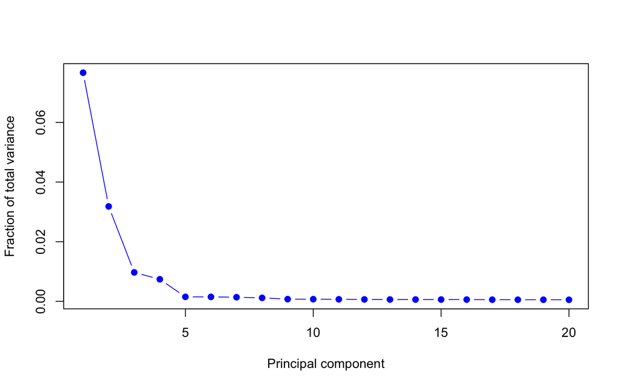

Figure 2. Fraction of total standardized genotype variance explained by each computed PC.

```r
ind.col.pca <- attr(obj.svd, "subset")
total_ss <- 0
for (first in seq.int(1L, length(ind.col.pca), by = 1024L)) {
  j <- first:min(first + 1023L, length(ind.col.pca))
  Z <- obj.bed[ind.norel, ind.col.pca[j], drop = FALSE]
  Z <- scale(Z, center = obj.svd$center[j], scale = obj.svd$scale[j])
  Z[is.na(Z)] <- 0
  total_ss <- total_ss + sum(Z^2)
}
rm(Z)
pve <- obj.svd$d^2 / total_ss
plot(pve, xlab = "Principal component", ylab = "Fraction of total variance",
     type = "b", pch = 19, col = "blue")
```

PC1 explains the most: 7.67% of total variance in this matrix.

### Q8: How much variance is enough?

Make a cumulative variance plot, then answer three questions:

1. Do the first 20 PCs reach 90% of total variation? Can this truncated fit tell you exactly how many PCs would be required?
2. A colleague plots `obj.svd$d / sum(obj.svd$d)` as proportions of total variance. Identify both mistakes.
3. Would reaching 90% be an appropriate rule for choosing GWAS covariates?

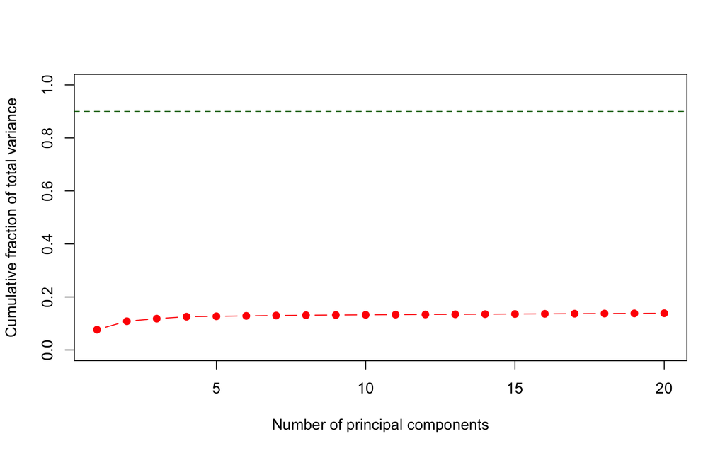

Figure 3. Cumulative variance explained, using the full variance denominator.

```r
cumulative_pve <- cumsum(pve)
plot(cumulative_pve, xlab = "Number of principal components",
     ylab = "Cumulative fraction of total variance", ylim = c(0, 1),
     type = "b", pch = 19, col = "red")
abline(h = 0.9, col = "darkgreen", lty = 2)
```

The first 20 PCs explain 13.86% of total variance. They do not reach 90%, so more than 20 PCs are needed; the exact number cannot be determined from these 20 singular values. The colleague’s expression makes two errors: variance requires squared singular values, and total variance requires the denominator from the full retained matrix. Normalizing `d^2` by `sum(d^2)` would instead force the cumulative sum of these 20 PCs to 100% and answer a different question.

The 90% target concerns reconstruction of this genotype matrix, not control of confounding. For GWAS, the relevant issue is which structure is associated with the phenotype and sampling process. Inspect ancestry, relatedness, LD and technical effects, and assess the chosen adjustment in the study design. The [PLINK PCA documentation](https://www.cog-genomics.org/plink/2.0/strat) explains why PCs can reflect technical effects or local genomic structure as well as ancestry. This exercise does not contain a phenotype or establish a sufficient covariate set.

### Q9: Plot the PCs pairwise.

You can color the plots based on the ancestral information from the .fam2 file in the data folder.

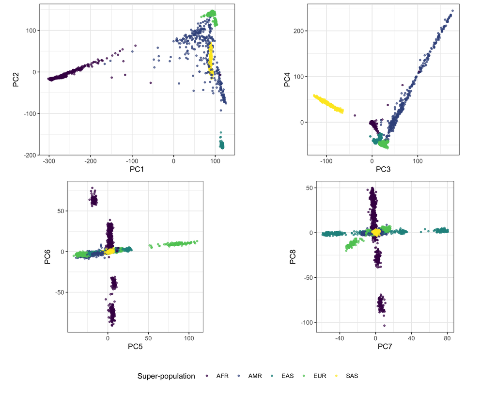

Figure 4. Initial PC pairs, colored by 1000 Genomes super-population labels.

```r
anc_info <- read.delim('data/1000G_phase3_common_norel.fam2')
stopifnot(!anyDuplicated(anc_info$sample.ID))
anc_info <- anc_info[match(obj.bed$fam$sample.ID, anc_info$sample.ID), ]
stopifnot(identical(anc_info$sample.ID, obj.bed$fam$sample.ID))
anc_fit <- anc_info[ind.norel, ]

initial_scores <- predict(obj.svd)
plot_pc_pairs <- function(scores, ancestry, role = NULL) {
  score_data <- as.data.frame(scores)
  names(score_data) <- paste0("PC", seq_len(ncol(scores)))
  score_data$Ancestry <- ancestry
  if (!is.null(role)) {
    score_data$Role <- factor(role, levels = c("Reference", "Projected: related",
                                              "Projected: outlier"))
    stopifnot(!anyNA(score_data$Role))
    score_data <- score_data[order(score_data$Role), ] # draw projections last
  }
  panels <- lapply(1:4, function(k) {
    p <- ggplot(score_data, aes(x = .data[[paste0("PC", 2*k-1)]],
                                y = .data[[paste0("PC", 2*k)]], color = Ancestry))
    if (is.null(role)) {
      p <- p + geom_point(size = 0.9, alpha = 0.7)
    } else {
      p <- p + geom_point(aes(shape = Role, size = Role, alpha = Role)) +
        scale_shape_manual(name = "Fit role", values = c(16, 5, 8), drop = FALSE) +
        scale_size_manual(values = c(0.9, 2, 2.5), guide = "none") +
        scale_alpha_manual(values = c(0.55, 1, 1), guide = "none") +
        guides(color = guide_legend(order = 1, nrow = 1),
               shape = guide_legend(order = 2, nrow = 1,
                 override.aes = list(size = c(1.5, 2, 2.5), alpha = 1)))
    }
    p + coord_fixed() +
      scale_color_viridis_d(name = "Super-population",
                            limits = c("AFR", "AMR", "EAS", "EUR", "SAS")) +
      theme_bw(base_size = 11)
  })
  legend <- cowplot::get_legend(panels[[1]] +
    theme(legend.position = "bottom", legend.box = "vertical"))
  grid <- cowplot::plot_grid(plotlist = lapply(panels, function(p)
    p + theme(legend.position = "none")), ncol = 2)
  cowplot::plot_grid(grid, legend, ncol = 1,
                     rel_heights = c(1, if (is.null(role)) 0.12 else 0.2))
}
plot_pc_pairs(initial_scores, anc_fit$Super.Population)
```

### Q10: What do PCs 3–8 distinguish in this panel? Use both `Super.Population` and `Population` labels, rather than only continental labels.

Use `Population.Description` in `anc_fit` to look up the population names. Figure 5 summarizes the population means, complementing the individual scores in Figure 4. Means are divided by the standard deviation of that PC across the reference individuals, solely to make the columns comparable in this display.

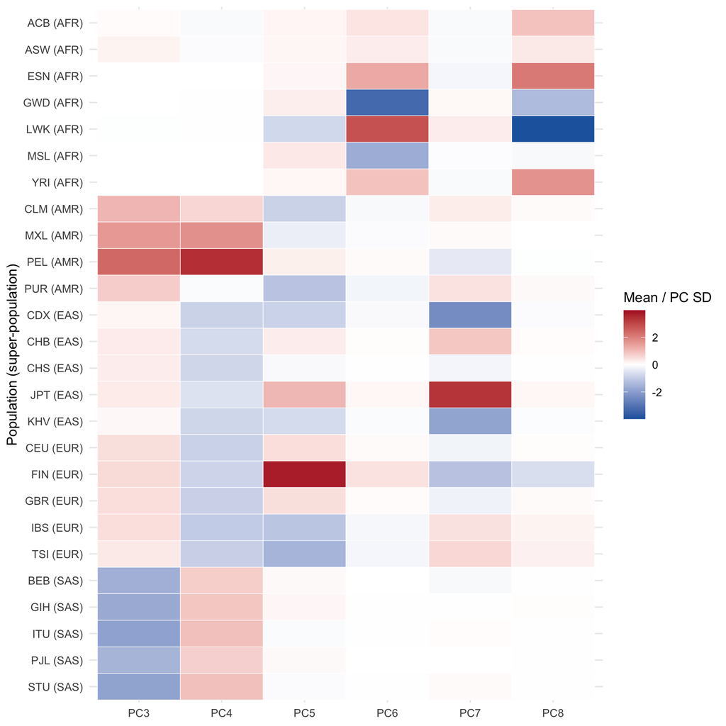

Figure 5. Population mean scores for PCs 3–8, in units of the reference sample standard deviation of each PC.

```r
pop_means <- aggregate(initial_scores[, 3:8], list(Population = anc_fit$Population), mean)
names(pop_means)[-1] <- paste0("PC", 3:8)
pop_labels <- unique(anc_fit[c("Population", "Super.Population")])
stopifnot(!anyDuplicated(pop_labels$Population))
pop_labels <- pop_labels[order(pop_labels$Super.Population, pop_labels$Population), ]
plot_means <- do.call(rbind, lapply(3:8, function(k) {
  data.frame(Population = pop_means$Population, PC = paste0("PC", k),
             MeanSD = pop_means[[paste0("PC", k)]] / sd(initial_scores[, k]))
}))
plot_means$Population <- factor(plot_means$Population, levels = rev(pop_labels$Population))
pop_axis <- setNames(paste0(pop_labels$Population, " (", pop_labels$Super.Population, ")"),
                     pop_labels$Population)
ggplot(plot_means, aes(PC, Population, fill = MeanSD)) +
  geom_tile(color = "white") + scale_y_discrete(labels = pop_axis) +
  scale_fill_gradient2(low = "#2166AC", mid = "white", high = "#B2182B",
                       limits = c(-1, 1) * max(abs(plot_means$MeanSD)),
                       name = "Mean / PC SD") +
  labs(x = NULL, y = "Population (super-population)") + theme_minimal(base_size = 11)
```

In this fit, PCs 3–4 distinguish South Asian groups and variation among the sampled admixed American groups. PC5 separates FIN from other European groups; PCs 6 and 8 distinguish several African groups; PC7 distinguishes East Asian groups including JPT and CDX/KHV. These are descriptions of the plotted panel, not universal meanings of those PC numbers. The mean plot hides within-population variation, which remains visible in Figure 4.

## 3. Assess outliers before refitting

**Before running:** would an isolated point necessarily be a bad genotype, or could the reference panel represent its ancestry poorly?

We now look for sample outliers in PC space. They may reflect genotyping issues or unusual ancestry; an outlier score alone cannot establish poor genotype quality. We retain the 2025 exercise threshold of 0.5 for this demonstration.

```r
prob <- bigutilsr::prob_dist(obj.svd$u, ncores = ncores)
S <- prob$dist.self / sqrt(prob$dist.nn)
stopifnot(all(is.finite(S)))
```

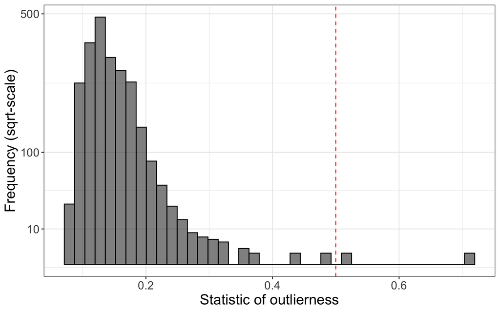

Figure 6. Sample outlier statistic; the red line marks the teaching threshold of 0.5.

```r
ggplot() +
  geom_histogram(aes(S), bins = 40, color = "#000000", fill = "#000000", alpha = 0.5) +
  geom_vline(xintercept = 0.5, color = "red", linetype = 2) +
  scale_y_sqrt(breaks = c(10, 100, 500)) +
  theme_bigstatsr() +
  labs(x = "Statistic of outlierness", y = "Frequency (sqrt-scale)")
```

### Q11: How many individuals are excluded at the outlier step? Compare the counts at cutoffs 0.4, 0.5, and 0.6.

Table 1 compares the cutoffs on the same initial fit; it does not rerun PCA three times.

```r
cutoff_counts <- data.frame(cutoff = c(0.4, 0.5, 0.6))
cutoff_counts$excluded <- vapply(cutoff_counts$cutoff, function(t) sum(S >= t), integer(1))
knitr::kable(cutoff_counts, caption = "Table 1. Samples excluded from the reference fit at three outlier cutoffs.")
```

Table 1. Samples excluded from the reference fit at three outlier cutoffs.

| cutoff | excluded |
| --- | --- |
| 0.4 | 4 |
| 0.5 | 2 |
| 0.6 | 1 |

### Q12: What does the outlier statistic measure? What evidence would you want before treating a flagged sample as a genotyping problem?

The calculation uses five nearest neighbours in the left singular vectors U. Let $a_i$ be the root mean squared distance from sample $i$ to those neighbours, and $b_i$ the mean of their own $a$-values. The statistic used here is

$$S_i = a_i / \sqrt{b_i}. \tag{2}$$

We exclude samples with $S_i \geq 0.5$ from the reference fit. This is a heuristic threshold in this representation, not a calibrated probability or proof of a genotyping error. The upstream vignette currently uses 0.6; this exercise preserves its original 0.5 and makes the sensitivity visible in Table 1. Before excluding samples from a real study, inspect genotype missingness, heterozygosity, assay batch and the ancestry composition of the reference panel. An ancestry group represented by very few people can look isolated without being a laboratory error.

**Now refit.** For this exercise, retain the chosen threshold of 0.5 so that everyone compares the same analysis. The sensitivity counts do not require three separate PCA fits.

```r
ind.row <- ind.norel[S < 0.5]
ind.col <- attr(obj.svd, "subset") # starting with the previous set of variants kept (we can therefore skip the initial clumping step)
set.seed(2027)
obj.svd2 <- bed_autoSVD(obj.bed, ind.row = ind.row,
                        ind.col = ind.col, thr.r2 = NA,
                        k = 20, ncores = ncores)
```

## 4. Project excluded samples and compare the fits

We would still like to obtain the PCA values for the remaining individuals. We do this by projecting the excluded individuals onto the newly derived PCs, to get PCs for all individuals.

```r
PCs <- matrix(NA_real_, nrow(obj.bed), ncol(obj.svd2$u))
PCs[ind.row, ] <- predict(obj.svd2)
ind.proj <- setdiff(rows_along(obj.bed), ind.row)

if (length(ind.proj)) {
  proj <- bed_projectSelfPCA(obj.svd2, obj.bed,
                            ind.row = ind.proj, ncores = 1)
  PCs[ind.proj, ] <- proj$OADP_proj
}
stopifnot(all(is.finite(PCs)))
```

### Q13: How do we project additional individuals? Which means, scales, variants, and allele coding must agree with the reference fit?

Distinguish exclusion from *fitting the reference PCs* from exclusion from the final score matrix. Mark projected individuals in a PC plot: how many were excluded because of relatedness, and how many because of the outlier statistic? For simple projection, center and scale the held-out genotypes using the *reference* means and scales, then multiply by the reference loadings:

$$T_{\mathrm{new}} = Z_{\mathrm{new}}
V_{\mathrm{ref}}. \tag{3}$$

Use the same retained variants in the same order and with the same allele coding. Estimate means and scales in the reference individuals and reuse them for projection; re-centering the held-out individuals would change the coordinate system. Simple projection can shrink projected scores. [`bed_projectSelfPCA()`](https://privefl.github.io/bigsnpr/reference/bed_projectSelfPCA.html) also returns OADP (Online Augmentation, Decomposition, and Procrustes) scores, which we use above to reduce that shrinkage.

Figure 7 distinguishes reference individuals (filled circles), individuals projected because of relatedness (open diamonds), and individuals projected after the outlier step (stars). The latter two groups did not define the reference axes. Signs are aligned to Figure 4 using shared reference individuals; the underlying fitted and projected scores remain unchanged.

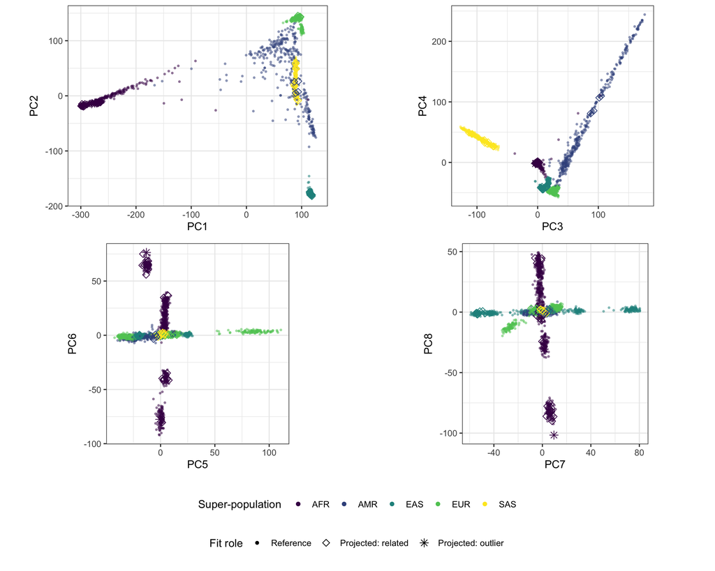

Figure 7. Final scores with signs aligned for display; shapes distinguish reference, related-projected and outlier-projected individuals.

```r
PCs_df <- as.data.frame(PCs)
colnames(PCs_df) <- paste0("PC", seq_len(ncol(PCs)))
PCs_df$Super.Population <- anc_info$Super.Population
score_cor <- cor(initial_scores[match(ind.row, ind.norel), ], predict(obj.svd2))
plot_sign <- ifelse(diag(score_cor) < 0, -1, 1)
PCs_for_plot <- sweep(PCs, 2, plot_sign, "*")
fit_role <- rep("Reference", nrow(PCs))
fit_role[ind.rel] <- "Projected: related"
fit_role[ind.norel[S >= 0.5]] <- "Projected: outlier"
plot_pc_pairs(PCs_for_plot, anc_info$Super.Population, role = fit_role)
```

### Q14: Compare the initial and final PCs on shared reference individuals. Do PCs 1–8 agree after allowing for sign changes? What happens to PCs 15–20?

Compare Figures 4 and 7, and compare scores on the individuals used in both fits. Signs may reverse without changing the PCA; near-tied components may also rotate. The second fit can change the retained variants as well as the samples.

```r
pc_cor <- abs(diag(cor(predict(obj.svd)[match(ind.row, ind.norel), 1:8],
                       predict(obj.svd2)[, 1:8])))
knitr::kable(data.frame(PC = 1:8, absolute_correlation = pc_cor), digits = 4,
             caption = "Table 2. Agreement of initial and refitted PC scores on shared reference individuals.")
```

Table 2. Agreement of initial and refitted PC scores on shared reference individuals.

| PC | absolute_correlation |
| --- | --- |
| 1 | 1.0000 |
| 2 | 1.0000 |
| 3 | 1.0000 |
| 4 | 1.0000 |
| 5 | 0.9976 |
| 6 | 0.9974 |
| 7 | 1.0000 |
| 8 | 0.9997 |

This run excludes 2 sample(s) at the outlier step and projects 60 individuals in total. Any change must be assessed from the computed comparison, rather than assuming that one excluded sample has no effect.

PCs 1–8 agree closely in Table 2. To inspect later PCs, use the full correlation matrix in Figure 8: high off-diagonal values indicate that a component can move to a different index. Other changes can reflect altered samples, retained variants or rotations among components with similar singular values; a low diagonal value alone does not distinguish these possibilities.

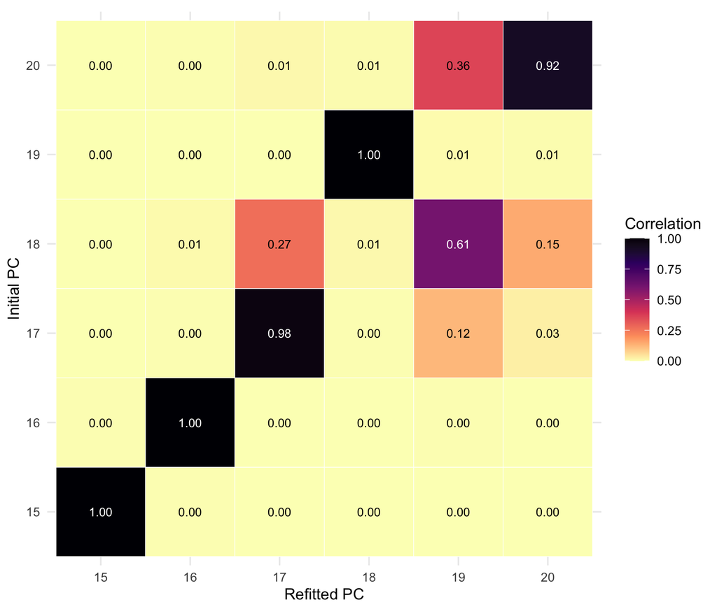

Figure 8. Absolute correlations between initial and refitted PCs 15–20 on shared reference individuals.

```r
later_cor <- expand.grid(Initial = 15:20, Refitted = 15:20)
later_cor$Correlation <- as.vector(abs(score_cor[15:20, 15:20]))
ggplot(later_cor, aes(factor(Refitted), factor(Initial), fill = Correlation)) +
  geom_tile(color = "white") +
  geom_text(aes(label = sprintf("%.2f", Correlation),
                color = ifelse(Correlation > 0.5, "white", "black")), size = 3) +
  scale_color_identity() +
  scale_fill_viridis_c(limits = c(0, 1), option = "magma", direction = -1) +
  coord_equal() + labs(x = "Refitted PC", y = "Initial PC") + theme_minimal(base_size = 11)
```

For example, initial PC19 has its strongest match to refitted PC18 in this run (absolute correlation 0.9999). The first eight PCs remain very similar, while some later components have changed more. Neither plot by itself tells us that confounding in a downstream GWAS has been adequately controlled.

**Check the sign issue.** Flipping one score axis leaves every pairwise distance unchanged. Using 100 individuals keeps this check small.

```r
A <- predict(obj.svd)[1:100, 1:8]
B <- A
B[, 1] <- -B[, 1]
sign_distances_match <- isTRUE(all.equal(as.vector(dist(A)), as.vector(dist(B))))
sign_distances_match
```

```
## [1] TRUE
```

**Example of a three-sentence analysis note.** The PCs describe variation among standardized genotypes in this reference panel; the first 20 explain 13.86% of that genotype variance, which is not a proportion of trait heritability. We excluded 58 related individuals and 2 further outliers from fitting the final reference axes, then projected them back to obtain scores for all 2490 individuals. Close agreement of PCs 1–8 supports the stability of these leading axes for this comparison, but choosing GWAS covariates still requires the phenotype, sampling design and further checks for confounding.